# Seurat v5 Pipeline

#### TSNE/UMAP

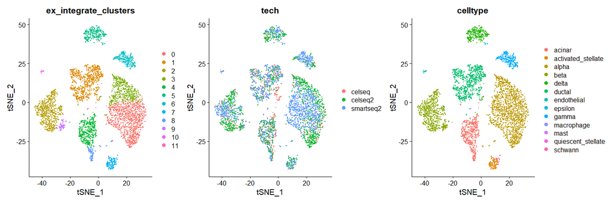

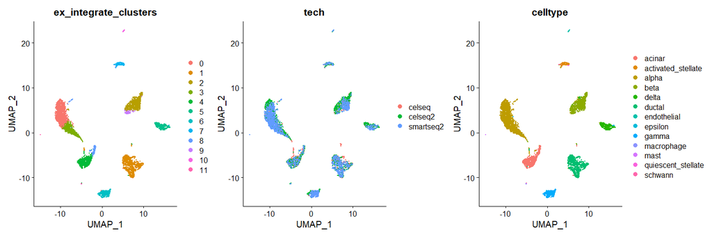

```r
# VISUALIZATION: TSNE/UMAP
## TSNE example
panc8_sub_integrate <- RunTSNE(panc8_sub_integrate, dims = 1:pcs, reduction.name = 'tsne_integrate')
DimPlot(object = panc8_sub_integrate, reduction = 'tsne_integrate', group.by = c('ex_integrate_clusters','tech','celltype'))

## UMAP example
panc8_sub_integrate <- RunUMAP(panc8_sub_integrate, dims = 1:pcs, reduction.name = 'umap_integrate')
DimPlot(object = panc8_sub_integrate, reduction = 'umap_integrate', group.by = c('ex_integrate_clusters','tech','celltype'))
### if want to use current identity, use 'ident' in group.by
```

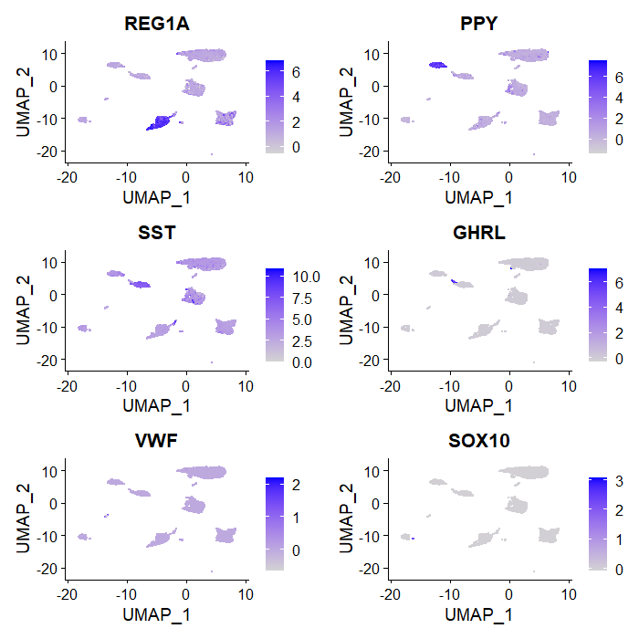

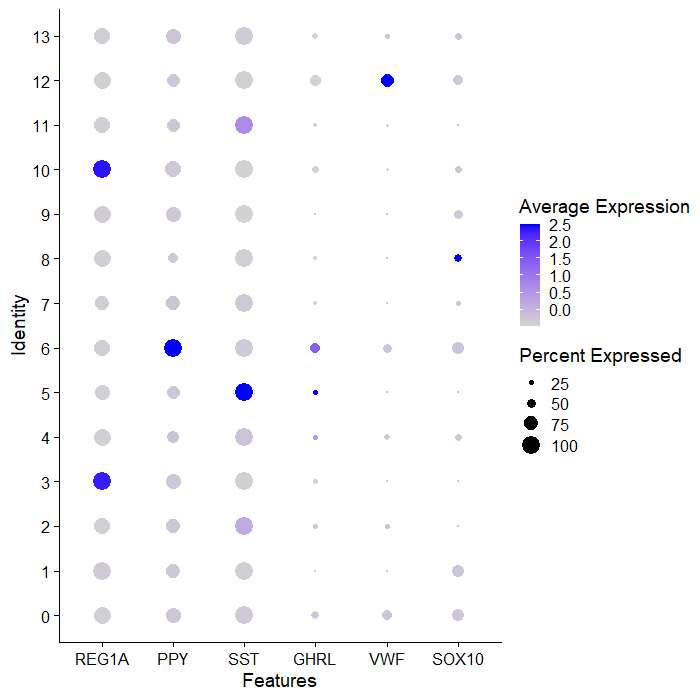

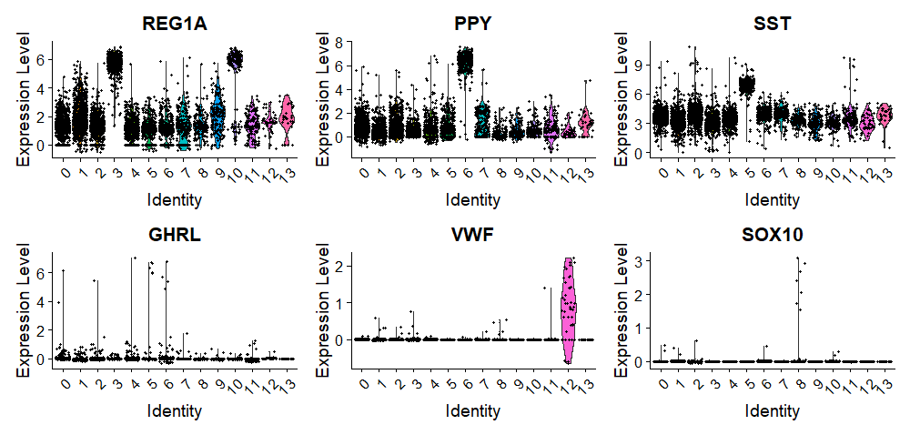

```r
## Visualizing expression
### can use these parameters to change plots: features, idents, split.by, group.by
FeaturePlot(panc8_sub_integrate, reduction = 'integrate_umap', features = c('REG1A', 'PPY', 'SST', 'GHRL', 'VWF', 'SOX10'))
DotPlot(panc8_sub_integrate, features = c('REG1A', 'PPY', 'SST', 'GHRL', 'VWF', 'SOX10'))
VlnPlot(panc8_sub_integrate, features = c('REG1A', 'PPY', 'SST', 'GHRL', 'VWF', 'SOX10'))
```

#### DE

```r
# DIFFERENTIAL EXPRESSION
## markers for cluster 0 (will compare cluster 1 to all other clusters)
cluster1_markers <- FindMarkers(object = panc8_sub_integrate, ident.1 = 0, min.pct = 0.25)
head(x = cluster1_markers, n = 5)

## markers for all clusters
panc8_sub_integrate_markers <- FindAllMarkers(object = panc8_sub_integrate, only.pos = TRUE, min.pct = 0.25, logfc.threshold = 0.25)

panc8_sub_integrate_markers %>% group_by(cluster) %>% top_n(n = 2, wt = avg_log2FC)
```

#### Conserved Features

Useful in finding conserved features among all conditions in dataset (ex: test and control). It can help if have any unknown clusters.

```r
# one cluster
panc8_sub_integrate_conserved_markers <- FindConservedMarkers(panc8_sub_integrate, ident.1 = 0, grouping.var = 'tech', only.pos = T)

# multiple clusters
get_conserved <- function(cluster) {
  FindConservedMarkers(panc8_sub_integrate, ident.1 = cluster, grouping.var = 'tech', only.pos = T) %>% rownames_to_column(var = 'gene') %>% cbind(cluster_id = cluster, .)
}

panc8_sub_integrate_conserved_markers <- map_dfr(c(0,1), get_conserved)
```

# Integration and Label Transfer

## Normalization and Finding Variable Features

```r
# Normalize and find variable features for each tech object
for (i in 1:length(pancreas.list)) {
  pancreas.list[[i]] <- NormalizeData(pancreas.list[[i]], verbose = F)
  pancreas.list[[i]] <- FindVariableFeatures(pancreas.list[[i]], selection.method = 'vst', nfeatures = 2000, verbose = F)
}
```

## Making Reference Dataset

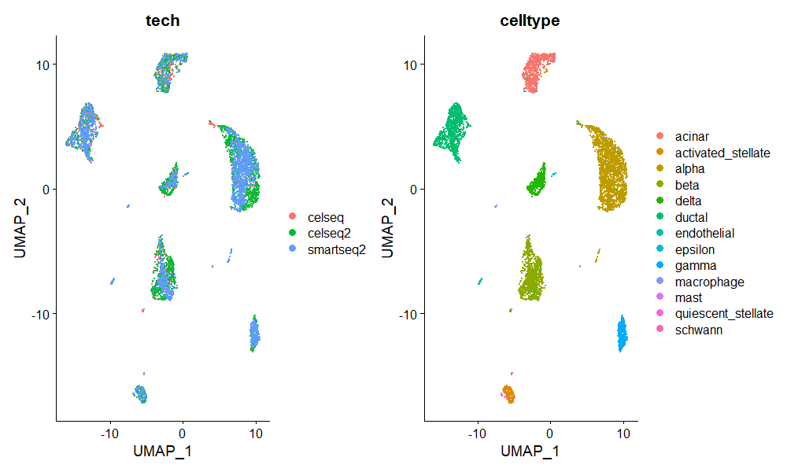

```r
# make reference object
reference.list <- pancreas.list[c('celseq', 'celseq2', 'smartseq2')]
## identify anchors
pancreas.anchors <- FindIntegrationAnchors(object.list = reference.list, dims = 1:30)
## integrate objects
pancreas.integrated <- IntegrateData(anchorset = pancreas.anchors, dims = 1:30)
## scaling and PCA
DefaultAssay(pancreas.integrated) <- 'integrated'
pancreas.integrated <- ScaleData(pancreas.integrated, verbose = F)
pancreas.integrated <- RunPCA(pancreas.integrated, npcs = 30, verbose = F)
pancreas.integrated <- RunUMAP(pancreas.integrated, reduction = 'pca', dims = 1:30)
## visualization
p1 <- DimPlot(pancreas.integrated, reduction = 'umap', group.by = 'tech')
p2 <- DimPlot(pancreas.integrated, reduction = 'umap', group.by = 'celltype', repel = T)
p1 + p2
```

## Label Tranferring

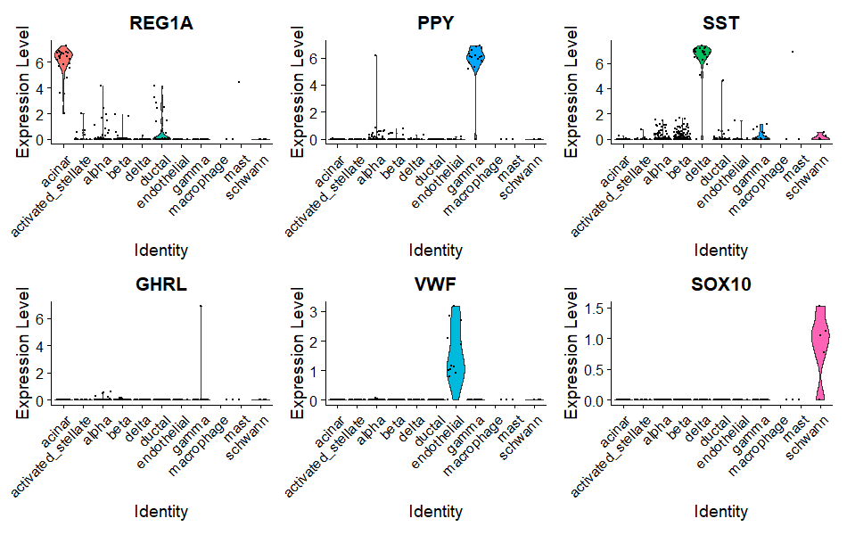

```r
# classifying cell type based on integrated reference
pancreas.query <- pancreas.list[['fluidigmc1']]
pancreas.anchors <- FindTransferAnchors(reference = pancreas.integrated, query = pancreas.query, dims = 1:30)
predictions <- TransferData(anchorset = pancreas.anchors, refdata = pancreas.integrated$celltype, dims = 1:30)
pancreas.query <- AddMetaData(pancreas.query, metadata = predictions)
## check predictions
pancreas.query$prediction.match <- pancreas.query$predicted.id == pancreas.query$celltype
table(pancreas.query$prediction.match)
## check predictions with canonical markers
table(pancreas.query$predicted.id)
VlnPlot(pancreas.query, c("REG1A", "PPY", "SST", "GHRL", "VWF", "SOX10"), group.by = 'predicted.id')
```

# SCTransform Integration Pipeline

SCTransform method takes the place of functions NormalizeData –> FindVariableFeatures –> ScaleData.

Links for more information about SCTransform: * https://hbctraining.github.io/scRNA-seq/lessons/06_SC_SCT_and_integration.html * https://satijalab.org/seurat/articles/sctransform_vignette.html

```r
# install example data
# InstallData('panc8')
data('panc8')
panc8 <- UpdateSeuratObject(panc8) # need to update cause old version

table(panc8$dataset)

panc8_sub <- SplitObject(panc8, split.by = 'dataset')
panc8_sub <- panc8_sub[c('celseq', 'celseq2', 'smartseq2')]

#rm(panc8)
```

## Cell Cycle Correction

In SCTransform pipeline, you need to check for cell cycle before running SCTransform.

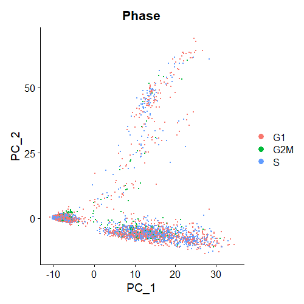

```r
cc_object <- merge(panc8_sub[[1]], c(panc8_sub[[2]], panc8_sub[[3]]))
cc_object <- NormalizeData(cc_object)

# cell cycle genes
s_genes <- cc.genes.updated.2019$s.genes
g2m_genes <- cc.genes.updated.2019$g2m.genes
## if have old gene names can use this function to change
cc.genes.updated.2019$s.genes <- UpdateSymbolList(cc.genes.updated.2019$s.genes)
cc.genes.updated.2019$g2m.genes <- UpdateSymbolList(cc.genes.updated.2019$g2m.genes)

cc_object <- CellCycleScoring(cc_object, s.features = s_genes, g2m.features = g2m_genes)

cc_object <- FindVariableFeatures(cc_object)
cc_object <- ScaleData(cc_object) # either with all genes or variable features
cc_object <- RunPCA(cc_object)
DimPlot(cc_object, reduction = 'pca', group.by = 'Phase')

# no problems with cell cycle correction

# if have cell cycle batch effects, then you will need to include that in vars.to.regress parameter in SCTransform function
```

## Processing

### QC

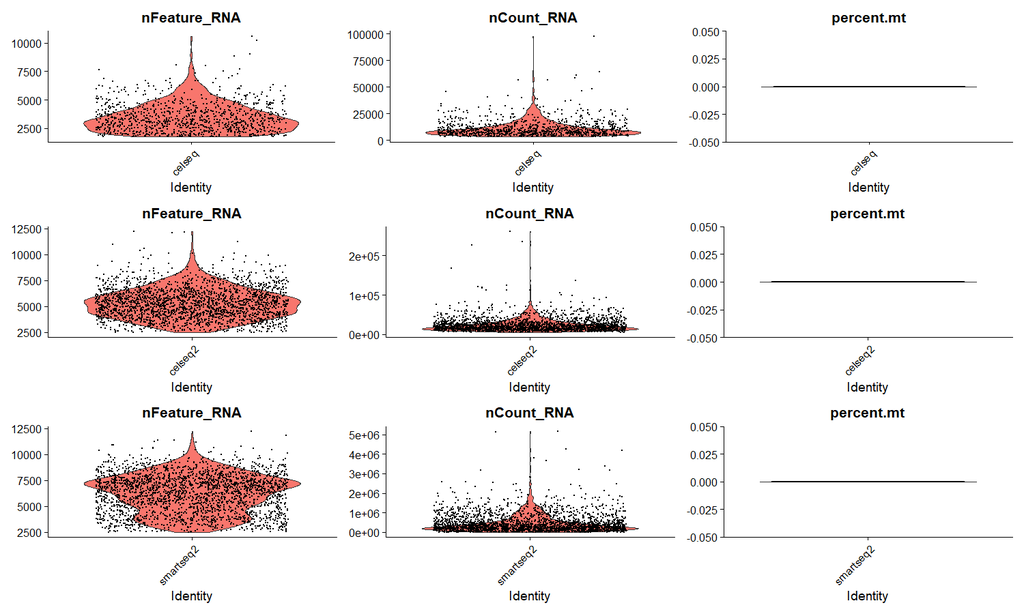

```r
# starting from split object list
for (i in 1:length(panc8_sub)) {
  panc8_sub[[i]][['percent.mt']] <- PercentageFeatureSet(panc8_sub[[i]], pattern = "^MT-")
}

plot_list <- list()
for (i in 1:length(panc8_sub)) {
  plot_list[[i]] <- VlnPlot(panc8_sub[[i]], features = c("nFeature_RNA", "nCount_RNA", "percent.mt"), ncol = 3, pt.size = .5)
}

plot_list[[1]] / plot_list[[2]] / plot_list[[3]]

# any filtering before doing the rest
```

### SCTransform

```r
for (i in 1:length(panc8_sub)) {
  panc8_sub[[i]] <- SCTransform(panc8_sub[[i]], vars.to.regress = 'nCount_RNA')
}
# can use glmGamPoi package for faster sctransform
```

### Integration –> Downstream Analysis

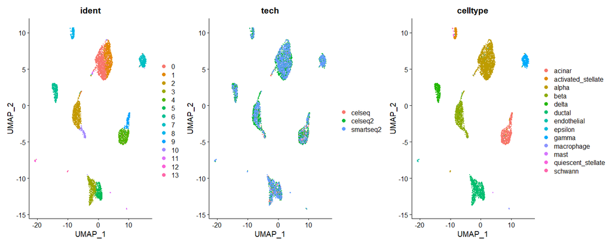

```r
features <- SelectIntegrationFeatures(panc8_sub, nfeatures = 3000)
panc8_sub <- PrepSCTIntegration(panc8_sub, anchor.features = features)
anchors <- FindIntegrationAnchors(panc8_sub, normalization.method = 'SCT', anchor.features = features)
panc8_sub_SCT_integrate <- IntegrateData(anchors, normalization.method = 'SCT')

panc8_sub_SCT_integrate <- RunPCA(panc8_sub_SCT_integrate)
panc8_sub_SCT_integrate <- RunUMAP(panc8_sub_SCT_integrate, dims = 1:30)

panc8_sub_SCT_integrate <- FindNeighbors(panc8_sub_SCT_integrate, dims = 1:30)
panc8_sub_SCT_integrate <- FindClusters(panc8_sub_SCT_integrate)

DimPlot(panc8_sub_SCT_integrate, group.by = c('ident', 'tech','celltype'))
```

# Batch Correction DE

```r
# DO NOT RUN
# only use if using methods negbinom, LR, MAST, DESeq2
panc8_batch_markers <- FindAllMarkers(object = panc8, only.pos = TRUE, min.pct = 0.25, logfc.threshold = 0.25, test.use = 'LR', latent.vars = 'tech')
```

Note:

- DE is done on the “data” slot. If you have batch corrected values, do not use corrected values for DE. It is better to include batch variables (latent.vars) in the model when running DE.

# Other Visualizations

Other visualization options and functions can be found here: https://satijalab.org/seurat/archive/v3.0/visualization_vignette.html

```r
# install example data
panc8_sub <- readRDS('example_datasets/example_objects/panc8_sub_process_merge_integrate.rds')
```

```r
# Get top n genes for each cluster through DE
Idents(panc8_sub) <- 'celltype'
markers <- FindAllMarkers(panc8_sub)
top10 <- markers %>% group_by(cluster) %>% top_n(n = 10, wt = avg_log2FC)
```

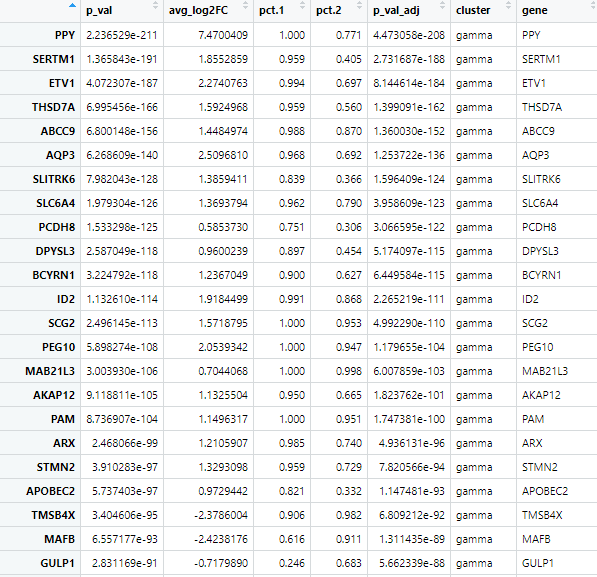

## Heatmaps

### DoHeatmap

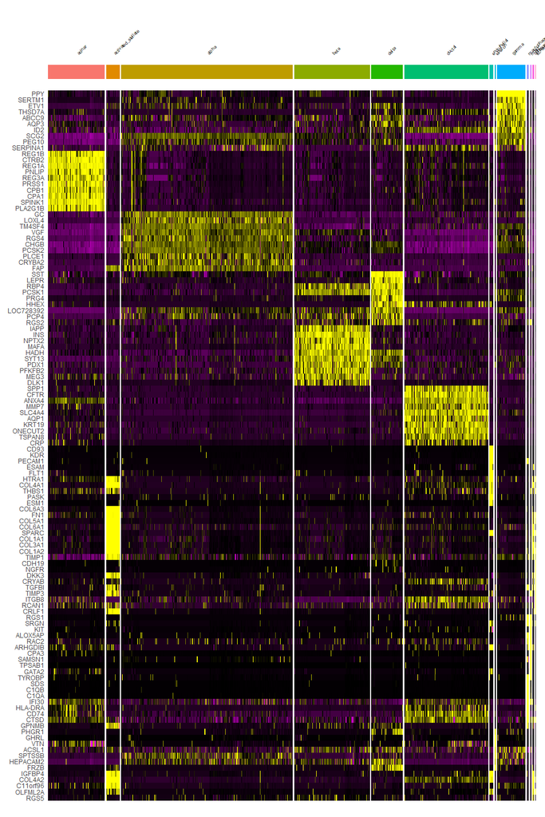

```r
DoHeatmap(object = panc8_sub, features = top10$gene, size = 2, group.by = 'celltype') + NoLegend()
```

### pheatmap

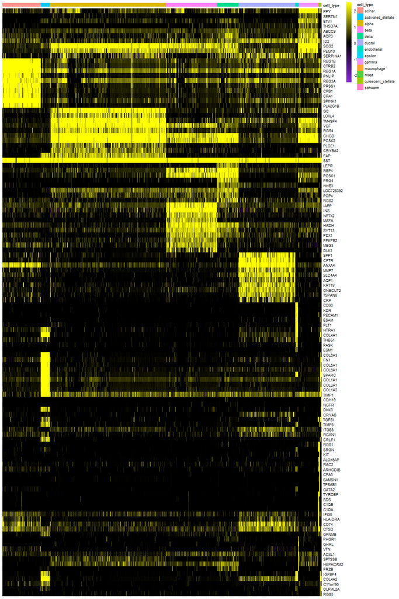

```r
## make sure when fetching data that there is no repeated genes
cells <- FetchData(object = panc8_sub, vars = c(unique(top10$gene), 'celltype'))
cells <- cells[order(cells$celltype),]

## creating annotation bars
anno <- data.frame(cell_type = cells$celltype)
rownames(anno) <- rownames(cells)

## rescaling
cells <- apply(cells[,1:(ncol(cells)-1)], MARGIN = 2, FUN = function(x) (squish(x, range = c(-2.5,2.5))))

pheatmap(mat = t(cells), show_colnames = F,
         cluster_rows = F, cluster_col = F,
         annotation_col = anno, fontsize = 7,
         color = colorRampPalette(colors = c('#8A2BE2','#000000','#FFFF00'))(250))
```

## Feature Plots

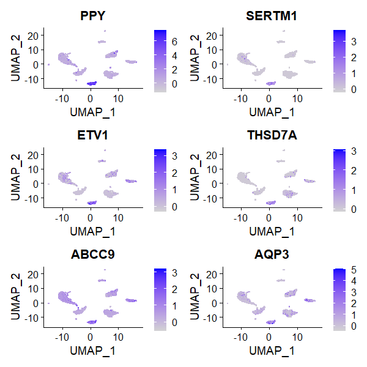

```r
FeaturePlot(panc8_sub, features = top10$gene[1:6])
```

## Violin Plots

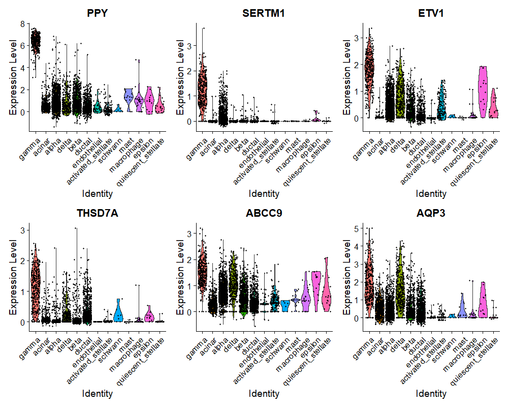

```r
VlnPlot(panc8_sub, features = top10$gene[1:6])
```

## Dot Plots

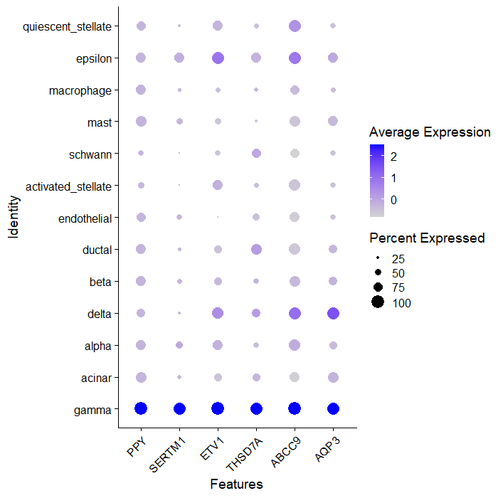

```r
DotPlot(panc8_sub, features = top10$gene[1:6]) + RotatedAxis()
```

## Ridge Plots

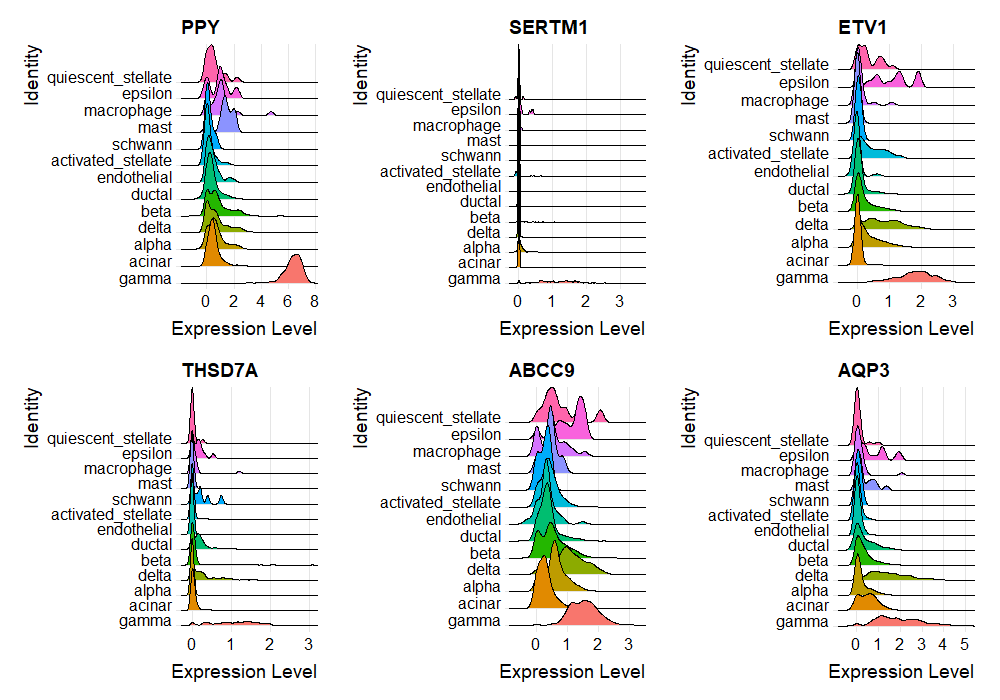

```r
RidgePlot(panc8_sub, features = top10$gene[1:6])
```